# W3cubDocs

#### Notes

**Masked arrays**

*C* may be a masked array. If `C[i, j]` is masked, the corresponding quadrilateral will be transparent. Masking of *X* and *Y* is not supported. Use `pcolor` if you need this functionality.

**Grid orientation**

The grid orientation follows the standard matrix convention: An array *C* with shape (nrows, ncolumns) is plotted with the column number as *X* and the row number as *Y*.

**Differences between pcolor() and pcolormesh()**

Both methods are used to create a pseudocolor plot of a 2D array using quadrilaterals.

The main difference lies in the created object and internal data handling: While `pcolor` returns a `PolyCollection`, `pcolormesh` returns a `QuadMesh`. The latter is more specialized for the given purpose and thus is faster. It should almost always be preferred.

There is also a slight difference in the handling of masked arrays. Both `pcolor` and `pcolormesh` support masked arrays for *C*. However, only `pcolor` supports masked arrays for *X* and *Y*. The reason lies in the internal handling of the masked values. `pcolor` leaves out the respective polygons from the PolyCollection. `pcolormesh` sets the facecolor of the masked elements to transparent. You can see the difference when using edgecolors. While all edges are drawn irrespective of masking in a QuadMesh, the edge between two adjacent masked quadrilaterals in `pcolor` is not drawn as the corresponding polygons do not exist in the PolyCollection.

Another difference is the support of Gouraud shading in `pcolormesh`, which is not available with `pcolor`.

## Examples using `matplotlib.axes.Axes.pcolormesh`

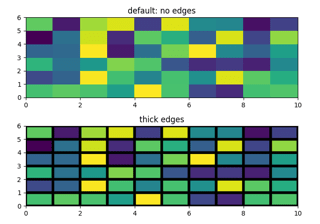

[Pcolor Demo](https://matplotlib.org/3.5.1/gallery/images_contours_and_fields/pcolor_demo.html#sphx-glr-gallery-images-contours-and-fields-pcolor-demo-py)

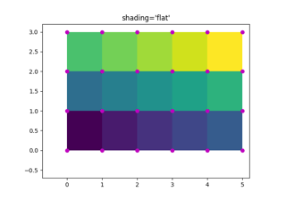

[pcolormesh grids and shading](https://matplotlib.org/3.5.1/gallery/images_contours_and_fields/pcolormesh_grids.html#sphx-glr-gallery-images-contours-and-fields-pcolormesh-grids-py)

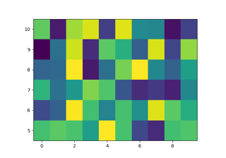

[pcolormesh](https://matplotlib.org/3.5.1/gallery/images_contours_and_fields/pcolormesh_levels.html#sphx-glr-gallery-images-contours-and-fields-pcolormesh-levels-py)

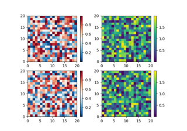

[Placing Colorbars](https://matplotlib.org/3.5.1/gallery/subplots_axes_and_figures/colorbar_placement.html#sphx-glr-gallery-subplots-axes-and-figures-colorbar-placement-py)

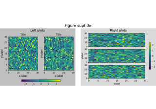

[Figure subfigures](https://matplotlib.org/3.5.1/gallery/subplots_axes_and_figures/subfigures.html#sphx-glr-gallery-subplots-axes-and-figures-subfigures-py)

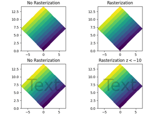

[Rasterization for vector graphics](https://matplotlib.org/3.5.1/gallery/misc/rasterization_demo.html#sphx-glr-gallery-misc-rasterization-demo-py)

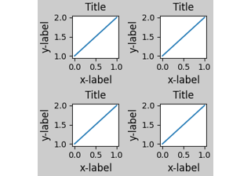

[Constrained Layout Guide](https://matplotlib.org/3.5.1/tutorials/intermediate/constrainedlayout_guide.html#sphx-glr-tutorials-intermediate-constrainedlayout-guide-py)

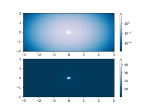

[Colormap Normalization](https://matplotlib.org/3.5.1/tutorials/colors/colormapnorms.html#sphx-glr-tutorials-colors-colormapnorms-py)

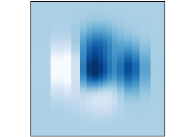

[pcolormesh(X, Y, Z)](https://matplotlib.org/3.5.1/plot_types/arrays/pcolormesh.html#sphx-glr-plot-types-arrays-pcolormesh-py)